# Part 2 : Exploratory Data Analysis (EDA)

In this part, we perform an Exploratory Data Analysis. We will clean and infer some first results based on our data sets.

## EDA for the seasons analysis

### Tokenization and cleaning of the data

As we know that we want to conduct a sentiment analysis on the the seasons of the series, we first define the corpus for our analysis. The corpus will be the *agg_scripts* column in our *season_scripts* data set as it contains all the texts that must be analysed. Once defined, we clean the texts by removing the numbers, the punctuation, the symbols, the separators and the stop words appearing in the English language.

In our scripts, we can see the main characters that are *Sheldon*, *Leonard*, *Penny*, *Howard* and *Raj*. They appear in each seasons’ episodes. Therefore, we remove their name for the following explanatory data analysis since it will otherwise bias our results.

We have created a variable *‘characters_names’* grouping the names of all the recurring characters during the series. Indeed, these are, logically, the words that come up the most often and this is not the purpose of our analysis here. It is the same with the words grouped in the variables *‘words_to_remove’*, which are themselves linked to the stage directions or do not bring any added value.

In here, we also perform the lemmatisation which is replacing some vocabulary by removing the inflectional endings and only keep the base or the corresponding form from the dictionary of word. It will give the lemma of each word from that dictionary.

### The Document-Term Matrix, the TF-IDF and the global frequencies

We use the TF-IDF method to look at the specificity of the terms through seasons. It allocates a weight to the most frequent words and translate a relevance of terms in the corpus. With the following graph, we can see that the most frequent term, is by far *‘Time’*. Indeed with the frequency matrix, we can see that *‘Time’* appears more than 900 times in the whole show.

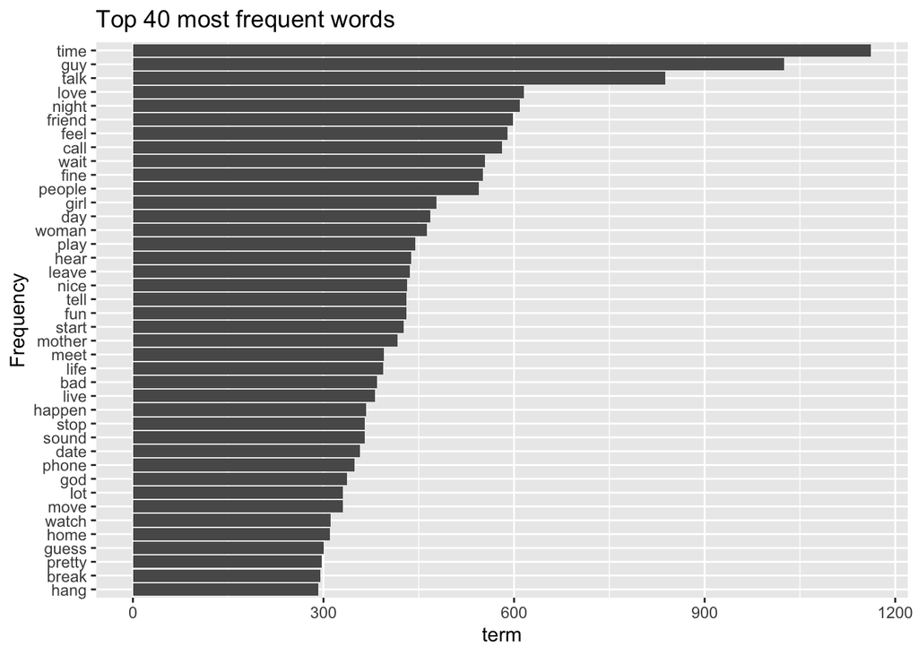

We observe that the most frequent terms are part of the feeling lexical field. For instance the words *‘love’*, *‘feel’*, *‘fine’*. With only this first representation, we can think of a positive pattern in the show.

### The 10 most frequent words per season

Then, we plot the 10 most frequent words per season and observe that it did not bring much information. Therefore we did not show the output of the graph here. Indeed, it is not really relevant because *‘time’* and *‘guy’* are always predominant through all the corpus and for each season, the plot was telling us the same thing. It looks logical to have them appearing individually.

### The TF-IDF per season

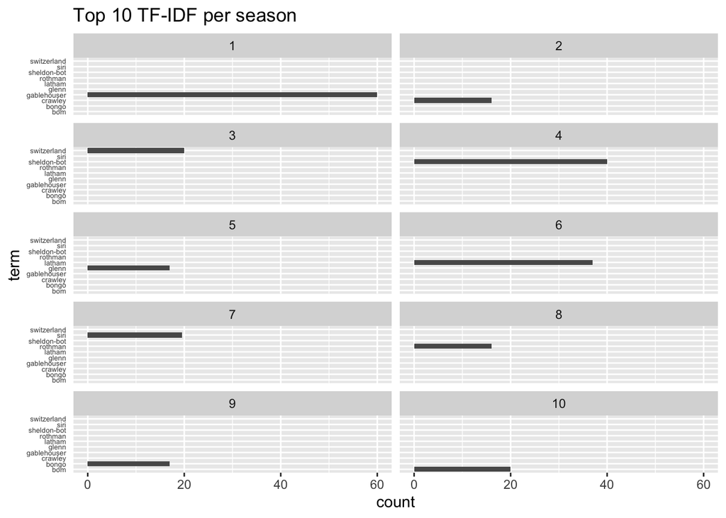

### Representation of the term frequencies

On this plot, we cannot see very clearly as there are a lot of terms. But we see that “time”, “guys” are indeed very frequent as seen previously and that “gablehouser” and “sheldon-bot” are very specific to one particular season each. For the term “gablehouser”, it is season 1 after research. In the show it is actually a character Dr. Eric Gablehauser, he does not appear in the show after the 2 first season and we did not notice him before to remove it with the other characters’ name.

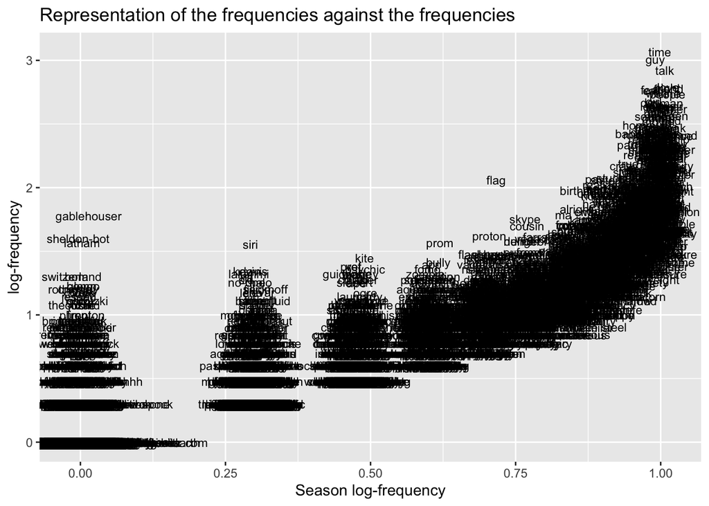

### Lexical diversity

We compute the lexical diversity of the scripts and we see that the season, especially the last (8, 10, 7, 9) do not have very diverse lexical. Indeed the TTR is equal to 0.25, which means that in a sequence of 4 words, 3 words are the same and only 1 is different. The season with the richest lexical seems to be the season 2 iwth a TTR score almost 0.5 .

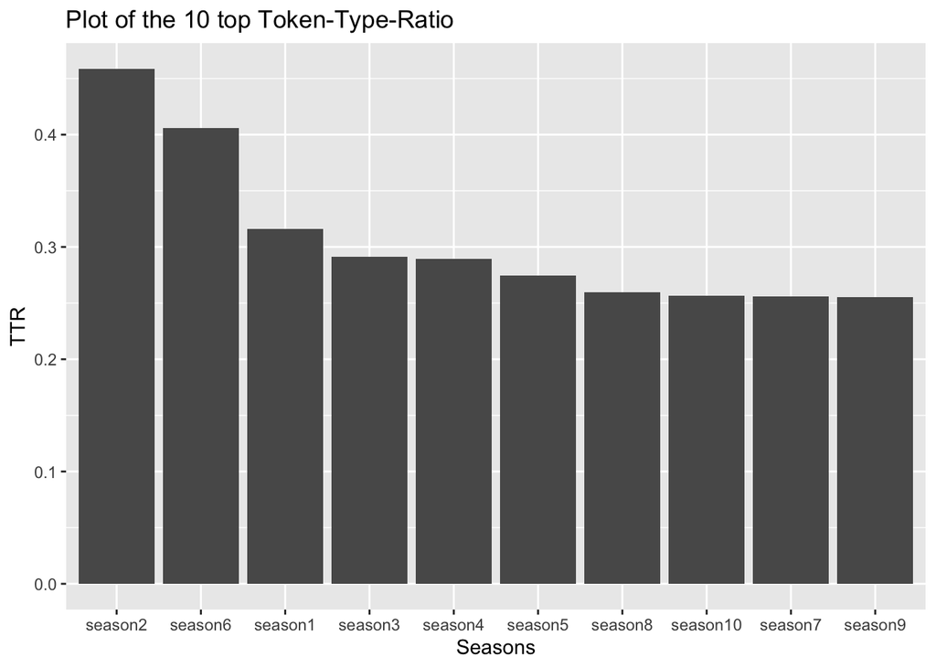

### Keyness analysis

We made a Keyness analysis, to understand what is the ration of the terms in the target compared to others in the rest of the corpus.

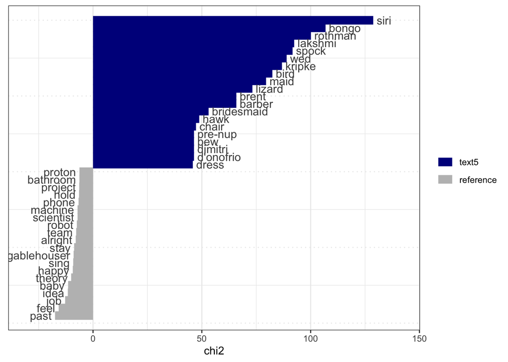

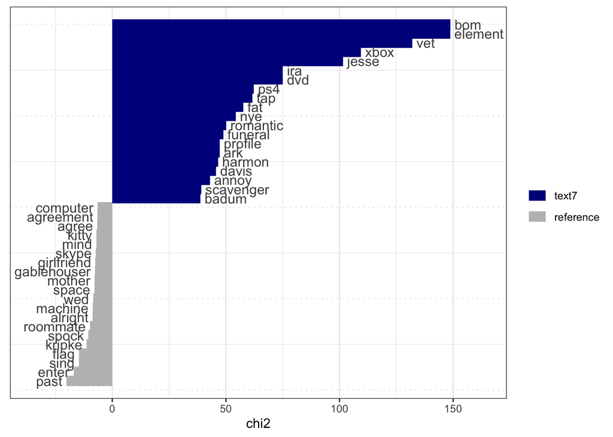

### Co-occurence analysis

Next, we decided to create a co-occurrence matrix to have an overview on which word often appears together.

The representation matrix helps us to understand how many times the most frequent words co-occur together in all the corpus. For example, *‘time’* and *‘guy’* co-occur 138’402 times together in the corpus, which means that they are used in the same context in the script.

Below is a plot of the co-occurrence graph. Each connection means that the two words appear together more than 30000 times. We see that at the center we have the terms *‘time’*, *‘talk’*, *‘guy’* which means that these words often appear along with the others.

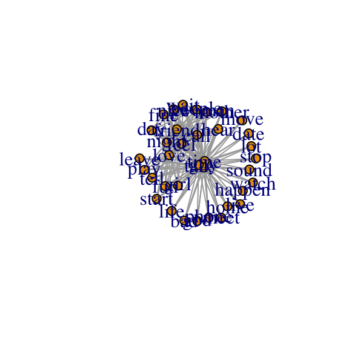

## EDA for the character analysis

### Tokenization and cleaning of the data

As with the season data we decided to make a tokenization and to do some pre-process cleaning of the data. Indeed, we removed all the numbers, punctuation, symbols, separators, stopwords, the same vector containing the characters’ names and the vector containing the words we judged not insightful for our analysis. Then we conducted a lemmatisation.

### The 10 most frequent words per character

We show here the most used words per character. We see that leonard often uses the word *‘love’* and Penny often uses the word *‘fine’*. Our first idea could be that Leonard is a very positive person, if the word *‘love’* is often pronounced by him.

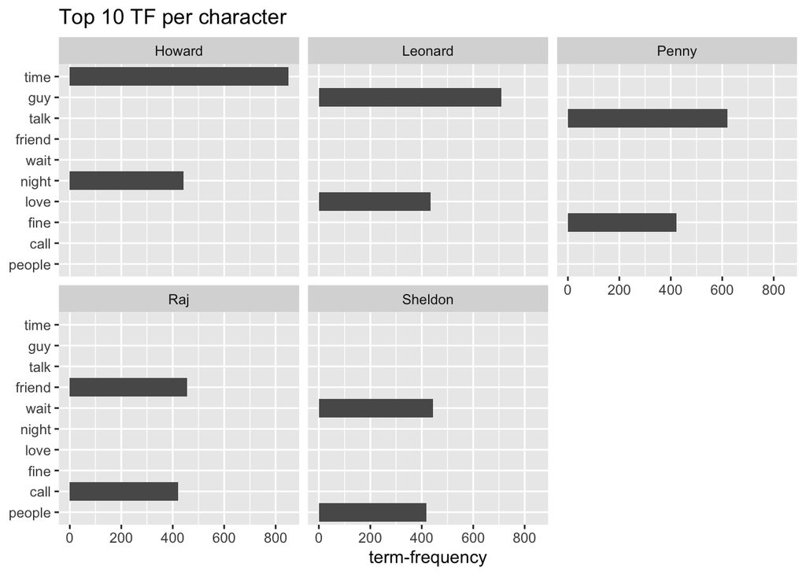

### The TF-IDF per character

Next we want to have an idea of what word is specific to which character. Therefore we plot the 10 most specific terms per character. Interestingly, the terms are very similar, but the allocation to the character is slightly different. From this plot, it seems that the word *‘remarkable’* are quite specific to the character Howard. While the terms *‘lord’* and *‘beverage’* are quite specific to Leonard. Maybe Penny has a tick word which is *‘hee’*, as it is quite very specific to her.

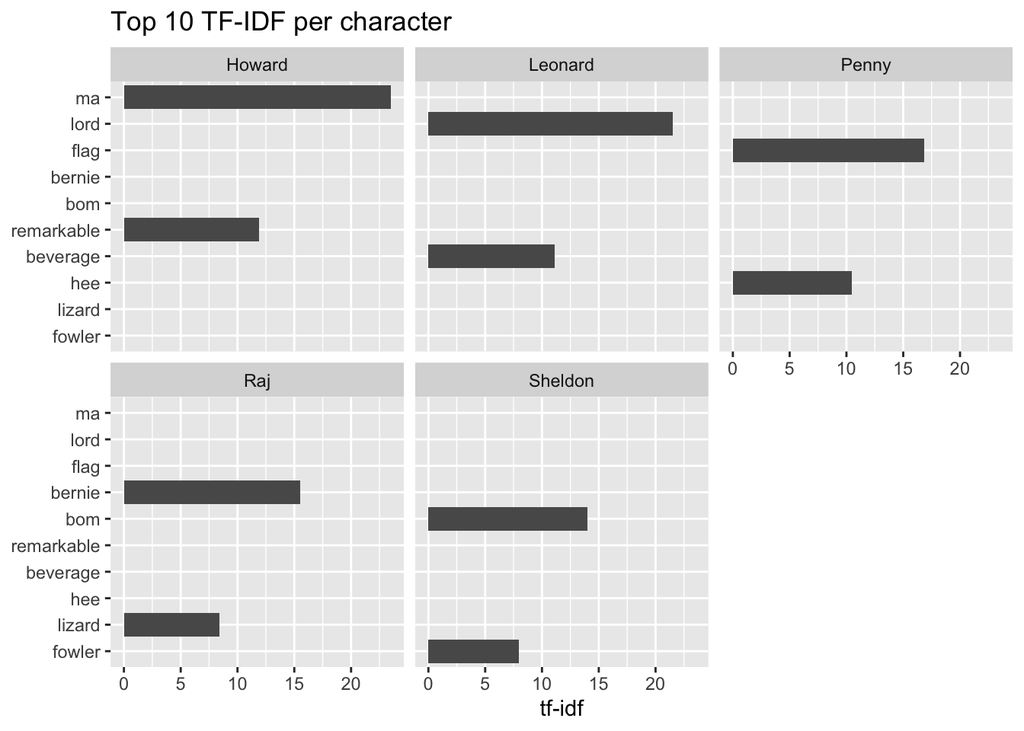

### Representation of the term frequencies

This plot allows us to confirm our first insight. Again, we have alreasy seen previously in the season analysis that terms such as *‘time’*, *‘guy’* and *‘talk’* are very frequent throughout the whole seasons and here they are present throughout each character so they are not specific to anyone. On the contrary, we see words such as *‘hee’* and *‘remarkable’* are very specific to a certain character.

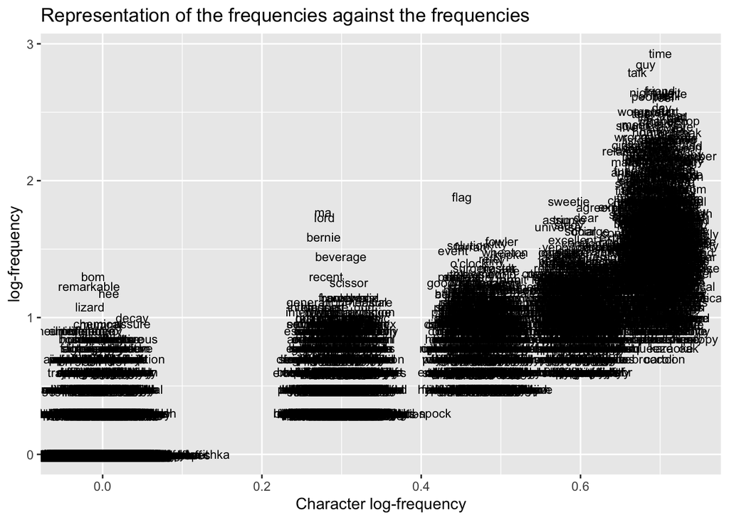

### Lexical diversity

We compute the lexical diversity of each character. It seems that Raj has the most diverse lexical with a Token-Type-Ratio of a bit mit more than 0.3. Indeed, in the series, he sometimes even speak in Hindi. Surprisingly, Sheldon has the less diverse vocabulary with a TTR of less 0.25, we were expecting more since he seemed to be the most well-known character of the series.

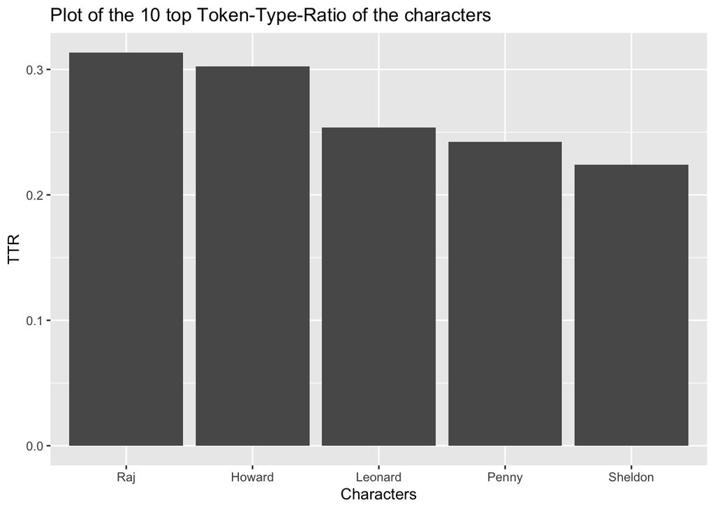

For the EDA of the character, we did not judge relevant to perform a co-occurrence analysis as the script is the same regardless if it is separated per season or per characters.